# Hands-on: Generalized Linear Models (GLM) untuk Data Asuransi

Latihan Linear, Logistik, Poisson/Negative Binomial, dan Gamma di R dengan data polis asuransi kendaraan `dataCar` (paket insuranceData)

# Part 0 · Persiapan

Tujuan latihan ini adalah mempraktikkan **regresi Linear, Logistik, Poisson (dan Negative Binomial), serta Gamma** pada data asuransi kendaraan: memilih variabel, memasang model, memeriksa asumsi, membaca `summary()`, menafsirkan koefisien, dan membuat prediksi.

## Cara membaca kode di modul ini

Setiap blok kode diberi label supaya Anda tahu mana yang harus dikuasai dan mana yang cukup dipahami:

| Label | Artinya | Yang perlu Anda lakukan |
| --- | --- | --- |
| **WAJIB** | Langkah inti analisis: menyiapkan data, memasang model (`lm()`, `glm()`), membaca koefisien, dan membuat prediksi. Tanpa kode ini analisis tidak jalan. | Pahami tiap baris dan **hafalkan polanya** (nama fungsi + argumen penting seperti `family`, `offset`, `type`). |
| **PELENGKAP** | Grafik diagnostik dan pengecekan hasil (`plot`, tabel kalibrasi, AUC). Membantu menilai model, tetapi model tetap jalan tanpanya. | Cukup tahu **pengecekan apa untuk model apa** dan cara membaca hasilnya. |
| **OPSIONAL** | Pembanding atau pendalaman (seleksi otomatis, uji tambahan, model alternatif). | Boleh dilewati jika waktu terbatas. |

Setiap baris kode diberi komentar `# ...` yang menjelaskan maksudnya. Di akhir modul ada **Contekan kode wajib** yang merangkum semua kode WAJIB dalam satu tempat untuk dihafal.

Di R, tanda `<-` berarti “simpan hasil ke dalam objek”. Contoh: `m <- glm(...)` artinya “pasang model GLM, simpan dengan nama `m`”. Tanda `$` mengambil bagian dari objek atau kolom dari data, misalnya `dataCar$clm`. Rumus `y ~ x1 + x2` dibaca “y dijelaskan oleh x1 dan x2”.

## Package yang dipakai

```r
# Memasang package dari CRAN. Cukup SEKALI per komputer, tidak perlu diulang tiap sesi.
install.packages(c("insuranceData",       # berisi data dataCar
                   "car",                 # vif(): cek multikolinearitas
                   "ResourceSelection"))  # hoslem.test(): hanya untuk bagian opsional
# MASS (glm.nb) sudah termasuk dalam instalasi R, tidak perlu dipasang.
```

```r
# Memuat package ke sesi R. WAJIB dijalankan setiap kali R dibuka ulang.
library(insuranceData)   # data dataCar
library(MASS)            # glm.nb() untuk Negative Binomial
library(car)             # vif()
data("dataCar", package = "insuranceData")   # memuat data ke memori R
```

## Data latihan: `dataCar`

Data `dataCar` dari package **insuranceData** berisi **67.856 polis asuransi kendaraan** satu tahun (periode 2004–2005, Australia), 4.624 di antaranya mengajukan klaim.

| Variabel | Arti | Jenis | Peran dalam GLM |
| --- | --- | --- | --- |
| `veh_value` | Nilai kendaraan, dalam satuan 10.000 AUD | numerik | Response Linear / predictor |
| `exposure` | Lama polis aktif dalam setahun (0–1) | numerik | Offset pada model frekuensi; predictor |
| `clm` | Ada klaim? (1 = ya, 0 = tidak) | biner | Response Logistik |
| `numclaims` | Jumlah klaim dalam periode polis | numerik (0–4) | Response Poisson / NB |
| `claimcst0` | Total biaya klaim (AUD; 0 jika tidak klaim) | numerik | Response Gamma (setelah difilter > 0) |
| `veh_body` | Jenis bodi kendaraan (SEDAN, HBACK = hatchback, STNWG = station wagon, UTE = pikap, dll.) | kategorik | Predictor |
| `veh_age` | Kelompok umur kendaraan: 1 = paling baru … 4 = paling tua | ordinal (tersimpan sebagai angka) | Predictor |
| `gender` | Jenis kelamin pengemudi (F/M) | kategorik | Predictor |
| `area` | Wilayah tempat tinggal (A–F) | kategorik | Predictor |
| `agecat` | Kelompok usia pengemudi: 1 = paling muda … 6 = paling tua | ordinal (tersimpan sebagai angka) | Predictor |
| `X_OBSTAT_` | Kolom teknis, isinya sama semua, tidak dipakai | – | – |

Pembagian pemakaian data:

| Bagian | Model | Response | Data yang dipakai |
| --- | --- | --- | --- |
| Part 2 | Regresi Linear | `veh_value` (kontinu) | Semua 67.856 polis |
| Part 3 | Regresi Logistik | `clm` (0/1) | Semua 67.856 polis |
| Part 4 | Poisson dan Negative Binomial | `numclaims` (count) | Semua 67.856 polis |
| Part 5 | Regresi Gamma | `claimcst0` (biaya positif) | 4.624 polis yang **mengajukan klaim** |

`veh_value` dipakai sebagai response Linear semata-mata agar mekanisme regresi linear bisa dipraktikkan pada dataset yang sama. Untuk memodelkan **risiko klaim**, pasangan yang sesuai adalah Logistik (ada/tidaknya klaim), Poisson/NB (frekuensi), dan Gamma (severitas).

```r
dim(dataCar)    # jumlah baris (polis) dan kolom (variabel)
```

```
#> [1] 67856    11
```

```r
head(dataCar)   # 6 baris pertama, untuk melihat bentuk data
```

| veh_value | exposure | clm | numclaims | claimcst0 | veh_body | veh_age | gender | area | agecat | X_OBSTAT_ |
| --- | --- | --- | --- | --- | --- | --- | --- | --- | --- | --- |
| 1.06 | 0.3039014 | 0 | 0 | 0 | HBACK | 3 | F | C | 2 | 01101 0 0 0 |
| 1.03 | 0.6488706 | 0 | 0 | 0 | HBACK | 2 | F | A | 4 | 01101 0 0 0 |
| 3.26 | 0.5694730 | 0 | 0 | 0 | UTE | 2 | F | E | 2 | 01101 0 0 0 |
| 4.14 | 0.3175907 | 0 | 0 | 0 | STNWG | 2 | F | D | 2 | 01101 0 0 0 |
| 0.72 | 0.6488706 | 0 | 0 | 0 | HBACK | 4 | F | C | 2 | 01101 0 0 0 |
| 2.01 | 0.8542094 | 0 | 0 | 0 | HDTOP | 3 | M | C | 4 | 01101 0 0 0 |

# Part 1 · Eksplorasi Data dan Pemilihan Variabel

Jangan langsung memasukkan semua variabel ke model. Pahami dulu tipe response dan predictor, lihat bentuk datanya, baru tentukan kandidat model.

**Alur berpikir:** tujuan analisis → tentukan response → pahami tipe response → pilih kandidat predictor → cek data → eksplorasi hubungan → cek korelasi/multikolinearitas → pasang model kandidat → bandingkan model → diagnostik → model final → interpretasi dan prediksi.

## Tipe variabel dan data hilang

```r
sapply(dataCar, class)                                  # tipe setiap kolom (numeric / factor / integer)
```

```
#> veh_value  exposure       clm numclaims claimcst0  veh_body   veh_age    gender
#> "numeric" "numeric" "integer" "integer" "numeric"  "factor" "integer"  "factor"
#>      area    agecat X_OBSTAT_
#>  "factor" "integer"  "factor"
```

```r
colSums(is.na(dataCar))                                 # jumlah data hilang per kolom
```

```
#> veh_value  exposure       clm numclaims claimcst0  veh_body   veh_age    gender
#>         0         0         0         0         0         0         0         0
#>      area    agecat X_OBSTAT_
#>         0         0         0
```

```r
lapply(dataCar[c("veh_body", "gender", "area")], table) # frekuensi variabel kategorik
```

```
#> $veh_body
#>
#>   BUS CONVT COUPE HBACK HDTOP MCARA MIBUS PANVN RDSTR SEDAN STNWG TRUCK   UTE
#>    48    81   780 18915  1579   127   717   752    27 22233 16261  1750  4586
#>
#> $gender
#>
#>     F     M
#> 38603 29253
#>
#> $area
#>
#>     A     B     C     D     E     F
#> 16312 13341 20540  8173  5912  3578
```

- `veh_age` dan `agecat` tersimpan sebagai **angka**, sehingga di dalam model diperlakukan sebagai variabel numerik (satu koefisien = efek linear per kenaikan satu kelompok). Jika ingin efek berbeda untuk tiap kelompok, ubah dengan `factor(agecat)` (lihat latihan di Part 3).
- Variabel bertipe **factor** (`gender`, `area`, `veh_body`) otomatis dijadikan variabel dummy oleh `lm()` dan `glm()`.

## Reference category

Pada variabel kategorik, R memakai **level pertama (urutan abjad)** sebagai pembanding. Semua koefisien dummy dibaca **terhadap kategori pembanding ini**.

```r
levels(dataCar$veh_body)    # level pertama = BUS (jarang muncul, kurang bermakna sebagai pembanding)
```

```
#>  [1] "BUS"   "CONVT" "COUPE" "HBACK" "HDTOP" "MCARA" "MIBUS" "PANVN" "RDSTR"
#> [10] "SEDAN" "STNWG" "TRUCK" "UTE"
```

```r
levels(dataCar$gender)      # pembanding = F
```

```
#> [1] "F" "M"
```

```r
levels(dataCar$area)        # pembanding = A
```

```
#> [1] "A" "B" "C" "D" "E" "F"
```

```r
# jadikan SEDAN (jenis paling umum) sebagai pembanding veh_body agar koefisien lebih mudah dibaca
dataCar$veh_body <- relevel(dataCar$veh_body, ref = "SEDAN")
levels(dataCar$veh_body)[1]
```

```
#> [1] "SEDAN"
```

`relevel(x, ref = "SEDAN")` hanya mengganti kategori pembanding; isi data tidak berubah. Di soal ujian, **selalu sebutkan kategori pembanding** ketika menafsirkan koefisien dummy.

## Eksplorasi response dan predictor

```r
round(prop.table(table(dataCar$clm)), 4)    # proporsi polis tanpa/dengan klaim
```

```
#>
#>      0      1
#> 0.9319 0.0681
```

```r
table(dataCar$numclaims)                     # sebaran jumlah klaim
```

```
#>
#>     0     1     2     3     4
#> 63232  4333   271    18     2
```

```r
summary(dataCar$claimcst0[dataCar$claimcst0 > 0])   # biaya klaim hanya untuk yang klaim
```

```
#>    Min. 1st Qu.  Median    Mean 3rd Qu.    Max.
#>   200.0   353.8   761.6  2014.4  2091.4 55922.1
```

```r
round(cor(dataCar[, c("veh_value", "exposure", "veh_age", "agecat")]), 2)   # korelasi antar predictor numerik
```

```
#>           veh_value exposure veh_age agecat
#> veh_value      1.00     0.00   -0.54  -0.06
#> exposure       0.00     1.00    0.04   0.03
#> veh_age       -0.54     0.04    1.00   0.02
#> agecat        -0.06     0.03    0.02   1.00
```

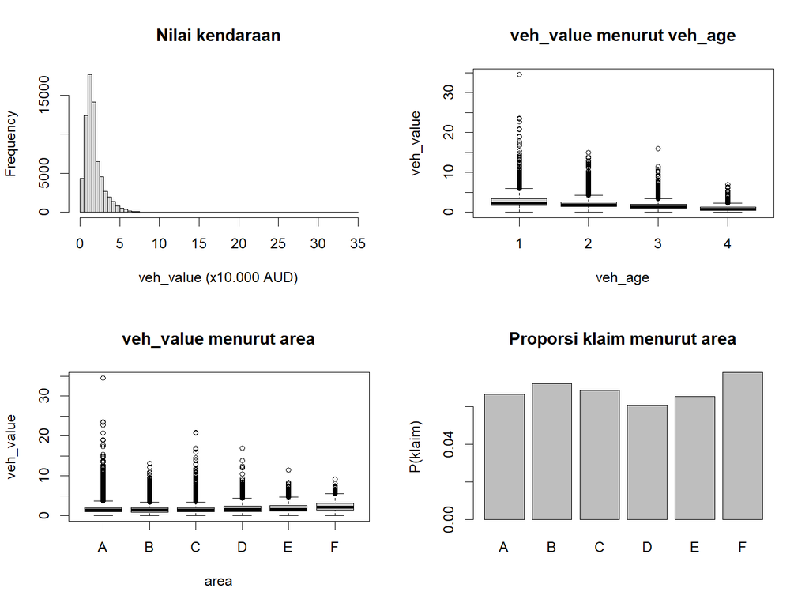

```r
par(mfrow = c(2, 2))                                   # 4 grafik dalam satu gambar
hist(dataCar$veh_value, breaks = 60, main = "Nilai kendaraan", xlab = "veh_value (x10.000 AUD)")
boxplot(veh_value ~ veh_age, data = dataCar, main = "veh_value menurut veh_age", ylab = "veh_value")
boxplot(veh_value ~ area, data = dataCar, main = "veh_value menurut area", ylab = "veh_value")
barplot(tapply(dataCar$clm, dataCar$area, mean), main = "Proporsi klaim menurut area",
        ylab = "P(klaim)")                              # tingkat klaim per wilayah
```

```r
par(mfrow = c(1, 1))
```

- Klaim adalah **kejadian jarang**: hanya 6.8% polis yang klaim. Ini penting untuk membaca probabilitas Logistik (nilainya akan kecil) dan mengevaluasi model.
- Sebagian besar polis punya `numclaims` = 0; hanya sedikit yang klaim 2 kali atau lebih. Ini ciri data **count** yang cocok untuk Poisson/NB.
- Biaya klaim miring ke kanan (banyak klaim kecil, sedikit klaim sangat besar): cocok untuk Gamma, bukan Linear biasa.
- `veh_value` juga miring ke kanan (banyak kendaraan murah, sedikit yang sangat mahal). Hal ini akan tampak lagi pada diagnostik model Linear di Part 2.
- Korelasi antar predictor numerik perlu diperiksa: korelasi yang sangat besar antar dua predictor adalah tanda awal multikolinearitas (dicek lebih formal dengan VIF).
- Variabel yang tampak berhubungan **belum otomatis harus masuk model**; keputusan mempertimbangkan tujuan, signifikansi, AIC, dan diagnostik.

Buat `boxplot(veh_value ~ gender, data = dataCar)` dan `boxplot(veh_value ~ veh_body, data = dataCar, las = 2)`. Jenis bodi mana yang median nilainya paling tinggi? Apakah ada dugaan bahwa `veh_body` layak masuk sebagai predictor `veh_value`?

# Part 2 · Regresi Linear

Kasus: menjelaskan **nilai kendaraan (`veh_value`)** dari karakteristik kendaraan dan pemegang polis. Response kontinu, link **identity**, koefisien langsung pada skala response.

## Memasang model

```r
model_lm_full <- lm(veh_value ~ veh_age + gender + area + agecat + exposure,   # response ~ predictor
                    data = dataCar)
summary(model_lm_full)   # tabel koefisien, R-squared, uji F
```

```
#>
#> Call:
#> lm(formula = veh_value ~ veh_age + gender + area + agecat + exposure,
#>     data = dataCar)
#>
#> Residuals:
#>     Min      1Q  Median      3Q     Max
#> -2.9567 -0.5563 -0.1992  0.3260 31.5448
#>
#> Coefficients:
#>              Estimate Std. Error  t value Pr(>|t|)
#> (Intercept)  3.368450   0.016301  206.644  < 2e-16 ***
#> veh_age     -0.622443   0.003539 -175.893  < 2e-16 ***
#> genderM      0.318002   0.007633   41.663  < 2e-16 ***
#> areaB       -0.097397   0.011463   -8.497  < 2e-16 ***
#> areaC       -0.078896   0.010298   -7.661 1.87e-14 ***
#> areaD        0.150103   0.013309   11.278  < 2e-16 ***
#> areaE        0.226657   0.014906   15.205  < 2e-16 ***
#> areaF        0.612230   0.018213   33.616  < 2e-16 ***
#> agecat      -0.036071   0.002662  -13.553  < 2e-16 ***
#> exposure     0.073069   0.013012    5.616 1.97e-08 ***
#> ---
#> Signif. codes:  0 '***' 0.001 '**' 0.01 '*' 0.05 '.' 0.1 ' ' 1
#>
#> Residual standard error: 0.9818 on 67846 degrees of freedom
#> Multiple R-squared:  0.3364, Adjusted R-squared:  0.3364
#> F-statistic:  3822 on 9 and 67846 DF,  p-value: < 2.2e-16
```

- Kolom `summary()`: **Estimate** (β), **Std. Error**, **t value** (uji t), dan `Pr` (p-value untuk H₀: β = 0).
- Aturan praktis: p-value < 0,05 → koefisien signifikan pada α = 5%.
- **Multiple R-squared** = proporsi variasi `veh_value` yang dijelaskan model; **F-statistic** menguji apakah minimal satu predictor berpengaruh.
- Nama koefisien dummy seperti `genderM` atau `areaB` berarti “kategori itu dibanding pembanding” (F dan A).
- Koefisien signifikan pada 5%: **veh_age, genderM, areaB, areaC, areaD, areaE, areaF, agecat, exposure**.
- Contoh membaca: `veh_age` = -0.622 artinya, dengan predictor lain tetap, naik satu kelompok umur kendaraan berkaitan dengan perubahan rata-rata `veh_value` sebesar -0.622 satuan (×10.000 AUD).
- Contoh dummy: jika `genderM` = 0,10, rata-rata `veh_value` pria diperkirakan 0,10 satuan lebih tinggi daripada wanita (pembanding), dengan predictor lain tetap.
- R² model ini = 0.336, artinya predictor yang dipakai menjelaskan 33.6% variasi nilai kendaraan. **Signifikan secara statistik tidak sama dengan berguna untuk prediksi**; pada n sebesar ini, efek kecil pun mudah signifikan, jadi lihat juga R².

## Pemilihan model

```r
model_lm_red <- lm(veh_value ~ veh_age + gender + area + agecat, data = dataCar)   # tanpa exposure
AIC(model_lm_full, model_lm_red)        # AIC lebih kecil = lebih baik (kompromi fit vs kompleksitas)
```

|  | df | AIC |
| --- | --- | --- |
| model_lm_full | 11 | 190091.3 |
| model_lm_red | 10 | 190120.8 |

```r
anova(model_lm_red, model_lm_full)      # uji F untuk model bersarang (nested)
```

| Res.Df | RSS | Df | Sum of Sq | F | Pr(>F) |
| --- | --- | --- | --- | --- | --- |
| 67847 | 65434.14 | NA | NA | NA | NA |
| 67846 | 65403.74 | 1 | 30.40116 | 31.53638 | 0 |

- `AIC()` boleh membandingkan model apa saja yang dipasang pada **data yang sama**. `anova()` hanya untuk model **bersarang** (model kecil adalah bagian dari model besar).
- Untuk satu variabel kategorik dengan banyak dummy (misalnya `area`), jangan menilai dari p-value tiap dummy saja: pakai `drop1(model, test = "F")` untuk menguji variabel itu secara keseluruhan.

```r
drop1(model_lm_full, test = "F")   # uji tiap variabel secara keseluruhan (semua dummy sekaligus)
```

|  | Df | Sum of Sq | RSS | AIC | F value | Pr(>F) |
| --- | --- | --- | --- | --- | --- | --- |
|  | NA | NA | 65403.74 | -2477.6725 | NA | NA |
| veh_age | 1 | 29824.49870 | 95228.24 | 23013.6297 | 30938.18567 | 0 |
| gender | 1 | 1673.30335 | 67077.04 | -765.4659 | 1735.78675 | 0 |
| area | 5 | 2022.13367 | 67425.87 | -421.4990 | 419.52857 | 0 |
| agecat | 1 | 177.06062 | 65580.80 | -2296.2213 | 183.67230 | 0 |
| exposure | 1 | 30.40116 | 65434.14 | -2448.1388 | 31.53638 | 0 |

## Diagnostik asumsi Linear

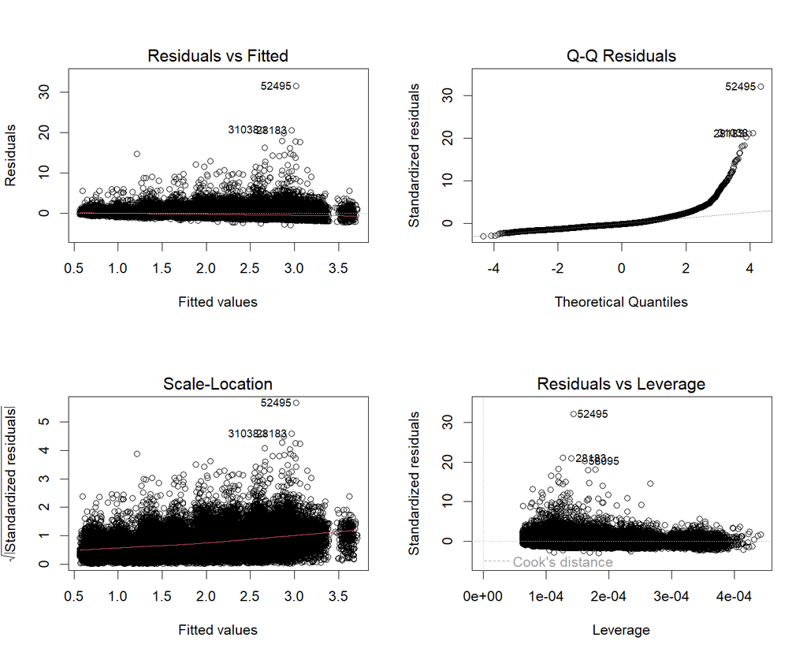

```r
par(mfrow = c(2, 2))
plot(model_lm_full)   # 1) Residuals vs Fitted  2) Normal Q-Q  3) Scale-Location  4) Residuals vs Leverage
```

```r
par(mfrow = c(1, 1))
```

```r
vif(model_lm_full)   # variance inflation factor: cek multikolinearitas
```

```
#>              GVIF Df GVIF^(1/(2*Df))
#> veh_age  1.004563  1        1.002279
#> gender   1.005745  1        1.002868
#> area     1.011861  5        1.001180
#> agecat   1.013407  1        1.006681
#> exposure 1.002384  1        1.001191
```

- **Residuals vs Fitted** (linearitas): idealnya titik tersebar acak di sekitar nol tanpa pola. Kurva atau pola melengkung = hubungan tidak linear.
- **Normal Q-Q** (normalitas residual): titik mengikuti garis diagonal. Ekor yang melengkung ke atas di kanan menandakan residual miring ke kanan, sesuai dengan `veh_value` yang miring.
- **Scale-Location** (homoskedastisitas): garis merah yang datar berarti ragam residual konstan; garis yang naik berarti ragam membesar seiring nilai prediksi.
- **Residuals vs Leverage**: titik di luar garis Cook’s distance adalah observasi berpengaruh.
- **VIF**: di bawah sekitar 5 (sebagian memakai 10) dianggap aman; VIF besar berarti predictor saling berkorelasi kuat dan koefisien tidak stabil. Untuk variabel factor seperti `area`, `vif()` mengeluarkan **GVIF**; baca kolom `GVIF^(1/(2*Df))` dan bandingkan dengan akar batas VIF (sekitar 2,2 untuk batas 5).
- Karena `veh_value` miring ke kanan dan ragamnya cenderung membesar, model Linear di sini **kurang ideal**. Salah satu perbaikan adalah transformasi log (chunk opsional di bawah).

```r
d_pos <- subset(dataCar, veh_value > 0)          # log(0) tidak terdefinisi -> buang nilai 0
model_lm_log <- lm(log(veh_value) ~ veh_age + gender + area + agecat, data = d_pos)
summary(model_lm_log)$r.squared                   # bandingkan dengan R-squared model awal
```

```
#> [1] 0.4580515
```

```r
exp(coef(model_lm_log))                           # efek MULTIPLIKATIF pada rata-rata geometrik veh_value
```

```
#> (Intercept)     veh_age     genderM       areaB       areaC       areaD
#>   3.9968929   0.6851980   1.1751420   0.9709272   0.9785306   1.1107437
#>       areaE       areaF      agecat
#>   1.1598829   1.4375021   0.9744580
```

Pada model dengan `log(y)`, `exp(β)` dibaca sebagai **faktor pengali** pada nilai response (kira-kira median), bukan penambahan satuan. Model Gamma dengan log link (Part 5) memberi tafsir pengali serupa tetapi pada **rata-rata** response.

- Tambahkan `veh_body` ke `model_lm_full`. Apakah AIC turun? Apakah `drop1(..., test = "F")` menunjukkan `veh_body` signifikan?
- Ubah `agecat` menjadi `factor(agecat)`. Apakah AIC lebih baik daripada memperlakukannya sebagai numerik?

# Part 3 · Regresi Logistik

Kasus: faktor apa yang berkaitan dengan **kemungkinan polis mengalami klaim**? Response `clm` bernilai 0/1, family **binomial**, link **logit**. Koefisien berada pada skala log-odds, sehingga hampir selalu ditafsirkan lewat `exp(β)` (odds ratio).

## Memasang model

```r
model_logit_full <- glm(clm ~ veh_value + exposure + veh_age + gender + area + agecat,
                        data = dataCar,
                        family = binomial(link = "logit"))   # family + link menentukan jenis GLM
summary(model_logit_full)
```

```
#>
#> Call:
#> glm(formula = clm ~ veh_value + exposure + veh_age + gender +
#>     area + agecat, family = binomial(link = "logit"), data = dataCar)
#>
#> Coefficients:
#>             Estimate Std. Error z value Pr(>|z|)
#> (Intercept) -3.27177    0.08471 -38.625  < 2e-16 ***
#> veh_value    0.03890    0.01452   2.679  0.00738 **
#> exposure     1.86305    0.05478  34.011  < 2e-16 ***
#> veh_age     -0.03839    0.01726  -2.224  0.02613 *
#> genderM     -0.02808    0.03159  -0.889  0.37398
#> areaB        0.08587    0.04639   1.851  0.06418 .
#> areaC        0.03618    0.04227   0.856  0.39200
#> areaD       -0.09898    0.05658  -1.750  0.08019 .
#> areaE       -0.02849    0.06200  -0.459  0.64593
#> areaF        0.06607    0.07138   0.926  0.35461
#> agecat      -0.09277    0.01097  -8.458  < 2e-16 ***
#> ---
#> Signif. codes:  0 '***' 0.001 '**' 0.01 '*' 0.05 '.' 0.1 ' ' 1
#>
#> (Dispersion parameter for binomial family taken to be 1)
#>
#>     Null deviance: 33767  on 67855  degrees of freedom
#> Residual deviance: 32450  on 67845  degrees of freedom
#> AIC: 32472
#>
#> Number of Fisher Scoring iterations: 6
```

- Struktur sama dengan `lm()`, ditambah `family`. Kolom uji sekarang **z value** (uji Wald), bukan t.
- `Null deviance` = deviance model tanpa predictor; `Residual deviance` = deviance model ini. Selisih yang besar berarti predictor membantu. **AIC** dipakai untuk membandingkan model.
- `Number of Fisher Scoring iterations` yang kecil (sekitar 4–6) menandakan model konvergen normal.

## Odds ratio dan interval kepercayaan

```r
OR <- exp(coef(model_logit_full))                          # odds ratio = exp(beta)
round(OR, 3)
```

```
#> (Intercept)   veh_value    exposure     veh_age     genderM       areaB
#>       0.038       1.040       6.443       0.962       0.972       1.090
#>       areaC       areaD       areaE       areaF      agecat
#>       1.037       0.906       0.972       1.068       0.911
```

```r
round(exp(cbind(OR = coef(model_logit_full),               # OR beserta selang kepercayaan 95% (Wald)
                confint.default(model_logit_full))), 3)
```

```
#>                OR 2.5 % 97.5 %
#> (Intercept) 0.038 0.032  0.045
#> veh_value   1.040 1.011  1.070
#> exposure    6.443 5.787  7.174
#> veh_age     0.962 0.930  0.995
#> genderM     0.972 0.914  1.034
#> areaB       1.090 0.995  1.193
#> areaC       1.037 0.954  1.126
#> areaD       0.906 0.811  1.012
#> areaE       0.972 0.861  1.098
#> areaF       1.068 0.929  1.229
#> agecat      0.911 0.892  0.931
```

- `exp(β) > 1` → odds klaim naik; `exp(β) < 1` → odds turun; `exp(β) = 1` → tidak berubah.
- Selang kepercayaan OR yang **memuat angka 1** setara dengan koefisien yang **tidak signifikan** pada 5%.
- `confint.default()` memakai pendekatan Wald (cepat). `confint()` memakai profile likelihood (lebih akurat tetapi lambat pada 67 ribu baris).
- Koefisien signifikan pada 5%: **veh_value, exposure, veh_age, agecat**.
- **Numerik**: `agecat` punya OR = 0.911. Artinya, dengan predictor lain tetap, naik satu kelompok usia pengemudi mengalikan **odds klaim** dengan 0.911. Nilai di bawah 1 = odds klaim turun.
- **Kategorik**: `genderM` punya OR = 0.972. Odds klaim pria adalah 0.972 kali odds klaim wanita (pembanding F), dengan predictor lain tetap.
- Yang dikalikan adalah **odds**, bukan probabilitas. Karena klaim jarang (probabilitas kecil), odds ≈ probabilitas, sehingga OR 1,2 kira-kira berarti peluang klaim sekitar 20% lebih tinggi secara relatif.

## Uji variabel secara keseluruhan dan pemilihan model

```r
drop1(model_logit_full, test = "Chisq")   # uji rasio likelihood: tiap variabel (semua dummy) keluar satu per satu
```

|  | Df | Deviance | AIC | LRT | Pr(>Chi) |
| --- | --- | --- | --- | --- | --- |
|  | NA | 32450.02 | 32472.02 | NA | NA |
| veh_value | 1 | 32456.90 | 32476.90 | 6.8846388 | 0.0086940 |
| exposure | 1 | 33669.65 | 33689.65 | 1219.6305184 | 0.0000000 |
| veh_age | 1 | 32454.96 | 32474.96 | 4.9445229 | 0.0261735 |
| gender | 1 | 32450.81 | 32470.81 | 0.7912085 | 0.3737349 |
| area | 5 | 32462.49 | 32474.49 | 12.4727009 | 0.0288544 |
| agecat | 1 | 32521.88 | 32541.88 | 71.8682967 | 0.0000000 |

```r
model_logit_red <- glm(clm ~ veh_age + gender + area + agecat,   # tanpa veh_value dan exposure
                       data = dataCar, family = binomial(link = "logit"))
AIC(model_logit_full, model_logit_red)                            # bandingkan AIC
```

|  | df | AIC |
| --- | --- | --- |
| model_logit_full | 11 | 32472.02 |
| model_logit_red | 9 | 33698.50 |

```r
anova(model_logit_red, model_logit_full, test = "Chisq")          # uji LRT untuk model bersarang
```

| Resid. Df | Resid. Dev | Df | Deviance | Pr(>Chi) |
| --- | --- | --- | --- | --- |
| 67847 | 33680.50 | NA | NA | NA |
| 67845 | 32450.02 | 2 | 1230.479 | 0 |

- `drop1(..., test = "Chisq")` menghasilkan **satu p-value per variabel**, termasuk `area` yang punya 5 dummy. Ini lebih tepat daripada melihat dummy satu per satu.
- `anova(model_kecil, model_besar, test = "Chisq")` = uji rasio likelihood (LRT); p-value kecil → variabel tambahan memperbaiki model secara berarti.
- Untuk GLM gunakan `test = "Chisq"` (Logistik, Poisson) atau `test = "F"` (Gamma, karena dispersi diestimasi).

```r
model_logit_step <- step(model_logit_full, direction = "both")   # seleksi otomatis berbasis AIC
summary(model_logit_step)
```

`step()` hanya alat bantu berbasis AIC, bukan pengganti pertimbangan statistik dan substantif. Variabel yang dikeluarkan `step()` tetap perlu ditinjau: apakah masuk akal secara bisnis?

## Prediksi probabilitas

```r
polis_baru <- data.frame(veh_value = 2, exposure = 0.8, veh_age = 2,   # satu profil polis baru
                         gender = "F", area = "C", agecat = 3)
predict(model_logit_full, newdata = polis_baru, type = "response")     # type = "response" -> probabilitas
```

```
#>         1
#> 0.1168692
```

- `newdata` harus memuat **semua predictor** dalam model dengan nama kolom yang sama. Untuk variabel factor, cukup tulis teks levelnya (`"F"`, `"C"`).
- `type = "response"` mengembalikan **probabilitas**; `type = "link"` (bawaan) mengembalikan log-odds η.
- Secara matematis: η = β₀ + β₁x₁ + … + βₚxₚ, lalu P(Y = 1) = e^η / (1 + e^η).

```r
pr <- predict(model_logit_full, newdata = polis_baru, type = "link", se.fit = TRUE)
plogis(pr$fit + c(-1.96, 0, 1.96) * pr$se.fit)   # batas bawah, estimasi, batas atas probabilitas (95%)
```

```
#> [1] 0.1101382 0.1168692 0.1239543
```

## Diagnostik dan kualitas model

```r
p_hat <- fitted(model_logit_full)                              # probabilitas prediksi tiap polis

# 1) Kalibrasi: bagi polis menjadi 10 kelompok menurut probabilitas prediksi, bandingkan prediksi vs kenyataan
desil <- cut(p_hat, quantile(p_hat, 0:10 / 10), include.lowest = TRUE, labels = 1:10)
round(data.frame(prediksi = tapply(p_hat, desil, mean),
                 aktual   = tapply(dataCar$clm, desil, mean)), 4)
```

| prediksi | aktual |
| --- | --- |
| 0.0263 | 0.0178 |
| 0.0329 | 0.0284 |
| 0.0387 | 0.0368 |
| 0.0452 | 0.0472 |
| 0.0535 | 0.0554 |
| 0.0635 | 0.0754 |
| 0.0761 | 0.0856 |
| 0.0915 | 0.0958 |
| 0.1110 | 0.1126 |
| 0.1428 | 0.1263 |

```r
# 2) AUC (kemampuan membedakan polis klaim vs tidak klaim), dihitung dari peringkat
auc <- function(y, p) { r <- rank(p); n1 <- sum(y == 1); n0 <- sum(y == 0)
                        (sum(r[y == 1]) - n1 * (n1 + 1) / 2) / (n1 * n0) }
auc(dataCar$clm, p_hat)
```

```
#> [1] 0.6588762
```

```r
# 3) Tabel klasifikasi memakai ambang = proporsi klaim keseluruhan (bukan 0,5)
table(Aktual = dataCar$clm, Prediksi = as.integer(p_hat > mean(dataCar$clm)))
```

```
#>       Prediksi
#> Aktual     0     1
#>      0 38344 24888
#>      1  1724  2900
```

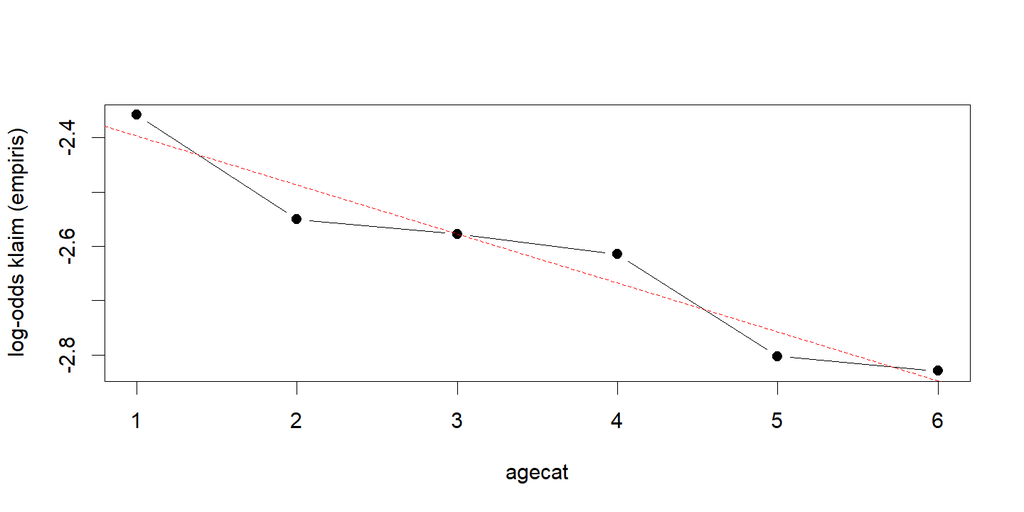

```r
# linearitas terhadap logit: log-odds klaim per kelompok usia (bandingkan dengan garis lurus)
emp <- aggregate(clm ~ agecat, data = dataCar, FUN = mean)
plot(emp$agecat, qlogis(emp$clm), type = "b", pch = 19,
     xlab = "agecat", ylab = "log-odds klaim (empiris)")
abline(lm(qlogis(emp$clm) ~ emp$agecat), lty = 2, col = "red")   # garis lurus sebagai pembanding
```

- **Kalibrasi**: kolom `prediksi` dan `aktual` sebaiknya berdekatan di semua desil. Selisih besar di suatu desil menandakan model salah pada kelompok itu.
- **AUC** = 0.659. Skala: 0,5 = sama dengan tebakan acak, 1 = sempurna. Nilai yang hanya sedikit di atas 0,5 (misalnya 0,55–0,65) berarti model **lemah dalam membedakan** polis klaim dan tidak klaim, meskipun beberapa koefisiennya signifikan: signifikan belum tentu berarti prediktif.
- **Tabel klasifikasi**: dengan ambang 0,5, hampir semua polis diprediksi “tidak klaim” karena klaim jarang. Karena itu ambang diturunkan ke proporsi klaim. Untuk kasus jarang, **akurasi bukan ukuran yang baik**; lihat kalibrasi dan AUC.
- **Linearitas logit**: jika titik menyimpang jauh dari garis putus-putus, perlakukan `agecat` sebagai kategorik (`factor(agecat)`) atau tambahkan suku non-linear.
- **Separation**: kalau ada koefisien yang sangat besar (misalnya puluhan) dengan standard error yang jauh lebih besar lagi, atau muncul warning `fitted probabilities numerically 0 or 1 occurred`, curigai separation. Pada model ini gejala itu tidak muncul.
- Plot bawaan `plot(model_logit)` kurang informatif untuk response 0/1 (residual membentuk dua pita), sehingga kalibrasi dan AUC lebih berguna.

```r
library(ResourceSelection)
hoslem.test(dataCar$clm, fitted(model_logit_full), g = 10)   # uji Hosmer-Lemeshow
```

Pada n sangat besar, uji Hosmer–Lemeshow hampir selalu menolak H₀ (model dianggap tidak cocok) karena sangat sensitif. Gunakan bersama tabel kalibrasi, jangan sendirian. Di dunia nyata, AUC juga sebaiknya dihitung pada **data uji** terpisah (train/test), bukan pada data yang sama dengan pemasangan model.

- Tambahkan `veh_body` ke model Logistik. Apakah AIC turun? Apa hasil `drop1(..., test = "Chisq")` untuk `veh_body`?
- Pasang ulang dengan `factor(agecat)`. Kelompok usia mana yang punya odds klaim paling tinggi terhadap kelompok 1? Apakah pola ini lurus?
- Prediksi probabilitas klaim untuk pengemudi pria, area F, `agecat` 1, kendaraan `veh_age` 4, `veh_value` 1, `exposure` 1.

# Part 4 · Regresi Poisson dan Negative Binomial

Kasus: memodelkan **frekuensi klaim** (`numclaims`). Response berupa count non-negatif, family **poisson**, link **log**. Lama pertanggungan tiap polis berbeda, sehingga `exposure` dimasukkan sebagai **offset**.

## Cek dispersion

Poisson mengasumsikan **equidispersion**: rata-rata sama dengan ragam.

```r
mean_claims <- mean(dataCar$numclaims)              # rata-rata jumlah klaim
var_claims  <- var(dataCar$numclaims)               # ragam jumlah klaim
c(mean = mean_claims, var = var_claims, indeks_dispersi = var_claims / mean_claims)
```

```
#>            mean             var indeks_dispersi
#>      0.07275701      0.07739737      1.06377882
```

Indeks dispersi = ragam / rata-rata = 1.064. Aturan baca: sekitar 1 → konsisten dengan Poisson; jauh di atas 1 → **overdispersion**; jauh di bawah 1 → underdispersion. Perhitungan ini kasar karena belum memperhitungkan `exposure` dan predictor; pengecekan yang lebih tepat memakai residual Pearson dari model (di bawah).

## Memasang model dengan offset exposure

```r
model_pois <- glm(numclaims ~ veh_value + veh_age + gender + area + agecat +
                    offset(log(exposure)),          # offset: koefisiennya dipaksa = 1, tidak diestimasi
                  data = dataCar,
                  family = poisson(link = "log"))
summary(model_pois)
```

```
#>
#> Call:
#> glm(formula = numclaims ~ veh_value + veh_age + gender + area +
#>     agecat + offset(log(exposure)), family = poisson(link = "log"),
#>     data = dataCar)
#>
#> Coefficients:
#>              Estimate Std. Error z value Pr(>|z|)
#> (Intercept) -1.505674   0.073132 -20.588   <2e-16 ***
#> veh_value    0.033254   0.013204   2.518   0.0118 *
#> veh_age     -0.039351   0.015920  -2.472   0.0134 *
#> genderM     -0.031348   0.029217  -1.073   0.2833
#> areaB        0.049382   0.042771   1.155   0.2483
#> areaC        0.004868   0.038975   0.125   0.9006
#> areaD       -0.118728   0.052545  -2.260   0.0238 *
#> areaE       -0.044656   0.057250  -0.780   0.4354
#> areaF        0.055571   0.065032   0.855   0.3928
#> agecat      -0.086862   0.010149  -8.559   <2e-16 ***
#> ---
#> Signif. codes:  0 '***' 0.001 '**' 0.01 '*' 0.05 '.' 0.1 ' ' 1
#>
#> (Dispersion parameter for poisson family taken to be 1)
#>
#>     Null deviance: 25507  on 67855  degrees of freedom
#> Residual deviance: 25386  on 67846  degrees of freedom
#> AIC: 34841
#>
#> Number of Fisher Scoring iterations: 6
```

- Model: log(E[klaim]) = log(exposure) + β₀ + β₁x₁ + …, sehingga E[klaim] = exposure × exp(β₀ + β₁x₁ + …). Yang dimodelkan adalah **laju klaim per satuan exposure (per tahun)**.
- Polis yang aktif setengah tahun otomatis dianggap punya harapan klaim setengahnya. Offset **tidak muncul** di tabel koefisien.
- Jangan memasukkan `exposure` sebagai predictor biasa untuk model frekuensi; itu berbeda maknanya dengan offset.

```r
IR <- exp(coef(model_pois))     # incidence rate ratio = exp(beta)
round(IR, 3)
```

```
#> (Intercept)   veh_value     veh_age     genderM       areaB       areaC
#>       0.222       1.034       0.961       0.969       1.051       1.005
#>       areaD       areaE       areaF      agecat
#>       0.888       0.956       1.057       0.917
```

- Koefisien signifikan pada 5%: **veh_value, veh_age, areaD, agecat**.
- `exp(β)` adalah **faktor pengali** pada frekuensi klaim yang diharapkan. `veh_value` punya `exp(β)` = 1.034: naik 1 satuan nilai kendaraan (10.000 AUD) mengalikan frekuensi klaim dengan 1.034, dengan predictor lain dan exposure tetap.
- `genderM` = 0.969: frekuensi klaim pria 0.969 kali frekuensi klaim wanita (pembanding F).
- Pada model log link, efek predictor bersifat **perkalian**: nilai `exp(β)` = 1,15 berarti kenaikan 15%, `exp(β)` = 0,90 berarti penurunan 10%.

## Cek overdispersion dari model

```r
# dispersi Pearson = jumlah kuadrat residual Pearson / derajat bebas residual
dispersion <- sum(residuals(model_pois, type = "pearson")^2) / df.residual(model_pois)
dispersion
```

```
#> [1] 1.41465
```

Dispersi Pearson = 1.415. Nilainya **sedikit di atas 1**: overdispersion ringan. Poisson masih bisa dipakai, tetapi bandingkan dengan Negative Binomial.

## Jika overdispersion: Negative Binomial

```r
model_nb <- glm.nb(numclaims ~ veh_value + veh_age + gender + area + agecat +
                     offset(log(exposure)),         # sintaks sama dengan Poisson, family tidak perlu ditulis
                   data = dataCar)
summary(model_nb)                                    # perhatikan Theta di bagian bawah
```

```
#>
#> Call:
#> glm.nb(formula = numclaims ~ veh_value + veh_age + gender + area +
#>     agecat + offset(log(exposure)), data = dataCar, init.theta = 2.198662258,
#>     link = log)
#>
#> Coefficients:
#>              Estimate Std. Error z value Pr(>|z|)
#> (Intercept) -1.507180   0.074957 -20.107   <2e-16 ***
#> veh_value    0.033906   0.013584   2.496   0.0126 *
#> veh_age     -0.038168   0.016292  -2.343   0.0191 *
#> genderM     -0.031530   0.029857  -1.056   0.2910
#> areaB        0.050678   0.043738   1.159   0.2466
#> areaC        0.006368   0.039835   0.160   0.8730
#> areaD       -0.117660   0.053601  -2.195   0.0282 *
#> areaE       -0.042992   0.058450  -0.736   0.4620
#> areaF        0.056005   0.066634   0.840   0.4006
#> agecat      -0.087368   0.010370  -8.425   <2e-16 ***
#> ---
#> Signif. codes:  0 '***' 0.001 '**' 0.01 '*' 0.05 '.' 0.1 ' ' 1
#>
#> (Dispersion parameter for Negative Binomial(2.1987) family taken to be 1)
#>
#>     Null deviance: 23532  on 67855  degrees of freedom
#> Residual deviance: 23416  on 67846  degrees of freedom
#> AIC: 34802
#>
#> Number of Fisher Scoring iterations: 1
#>
#>
#>               Theta:  2.199
#>           Std. Err.:  0.398
#>
#>  2 x log-likelihood:  -34780.033
```

```r
AIC(model_pois, model_nb)                            # bandingkan Poisson vs NB
```

|  | df | AIC |
| --- | --- | --- |
| model_pois | 10 | 34840.96 |
| model_nb | 11 | 34802.03 |

- `glm.nb()` berasal dari package **MASS**. **Theta** adalah parameter dispersi NB: **makin besar theta, makin mirip Poisson**. Theta yang sangat besar berarti data hampir equidispersed.
- Tafsir koefisien NB dengan log link **sama** dengan Poisson: `exp(β)` = pengali frekuensi.
- Alternatif yang lebih ringan: `glm(..., family = quasipoisson)`, yang mengoreksi standard error dengan dispersi tetapi tidak menghasilkan AIC.

```r
k <- 0:4                                                            # nilai numclaims yang ada
obs      <- as.vector(table(factor(dataCar$numclaims, levels = k))) # frekuensi teramati
exp_pois <- sapply(k, function(j) sum(dpois(j, fitted(model_pois))))                     # frekuensi harapan Poisson
exp_nb   <- sapply(k, function(j) sum(dnbinom(j, size = model_nb$theta, mu = fitted(model_nb))))  # frekuensi harapan NB
round(data.frame(numclaims = k, teramati = obs, poisson = exp_pois, nb = exp_nb), 1)
```

| numclaims | teramati | poisson | nb |
| --- | --- | --- | --- |
| 0 | 63232 | 63162.9 | 63253.1 |
| 1 | 4333 | 4458.8 | 4283.1 |
| 2 | 271 | 225.1 | 297.1 |
| 3 | 18 | 8.9 | 21.1 |
| 4 | 2 | 0.3 | 1.5 |

- AIC Poisson = 3.4841^{4}, AIC NB = 3.4802^{4}. AIC NB **lebih kecil**, sehingga NB dipilih.
- Tabel di atas membandingkan jumlah polis **teramati** dengan **harapan** menurut tiap model. Model yang baik menghasilkan angka harapan yang dekat dengan angka teramati, terutama pada klaim 0 dan ≥ 2.
- Perhatikan apakah koefisien dan kesimpulan signifikansi berubah antara Poisson dan NB. Bila hampir sama, kesimpulan Anda kokoh terhadap pilihan model.

## Prediksi frekuensi

```r
polis_frek <- data.frame(veh_value = 2, veh_age = 2, gender = "F", area = "C",
                         agecat = 3, exposure = 1)                  # exposure = 1 tahun penuh
predict(model_pois, newdata = polis_frek, type = "response")        # harapan jumlah klaim per tahun
```

```
#>         1
#> 0.1697232
```

`predict(..., type = "response")` pada model beroffset sudah memasukkan offset, sehingga hasilnya = **harapan jumlah klaim untuk exposure yang Anda tuliskan di `newdata`**. Dengan `exposure = 1` hasilnya adalah frekuensi tahunan; dengan `exposure = 0.5` hasilnya separuhnya.

- Tambahkan `veh_body` ke model Poisson. Apakah AIC turun?
- Prediksi frekuensi klaim yang sama dengan `exposure = 0.25`. Apakah hasilnya tepat seperempat dari `exposure = 1`? Mengapa?
- Pasang `glm(..., family = quasipoisson)` dan bandingkan standard error dengan Poisson biasa.

# Part 5 · Regresi Gamma

Kasus: memodelkan **besar biaya klaim (severitas)**. `claimcst0` bernilai 0 untuk polis tanpa klaim, sehingga Gamma dipasang hanya pada polis dengan biaya klaim **positif**. Family **Gamma**, link **log**.

## Menyiapkan data severitas

```r
data_gamma <- subset(dataCar, claimcst0 > 0)   # hanya polis dengan biaya klaim positif
nrow(data_gamma)                               # jumlah polis
```

```
#> [1] 4624
```

```r
summary(data_gamma$claimcst0)                  # ringkasan biaya klaim
```

```
#>    Min. 1st Qu.  Median    Mean 3rd Qu.    Max.
#>   200.0   353.8   761.6  2014.4  2091.4 55922.1
```

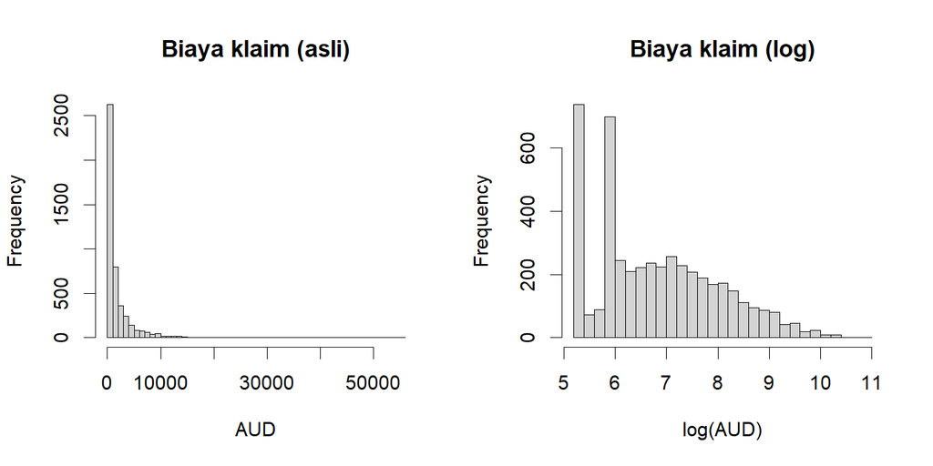

```r
par(mfrow = c(1, 2))
hist(data_gamma$claimcst0, breaks = 60, main = "Biaya klaim (asli)", xlab = "AUD")
hist(log(data_gamma$claimcst0), breaks = 40, main = "Biaya klaim (log)", xlab = "log(AUD)")
```

```r
par(mfrow = c(1, 1))
```

Distribusi biaya klaim **miring ke kanan dan positif**, sedangkan setelah di-log mendekati simetris. Ciri ini sesuai untuk Gamma: response kontinu positif dengan ragam yang membesar seiring rata-rata (koefisien variasi kira-kira konstan). Regresi Linear biasa pada biaya mentah akan melanggar asumsi kenormalan dan kehomogenan ragam.

## Memasang model

```r
model_gamma <- glm(claimcst0 ~ veh_value + exposure + veh_body + veh_age + gender + area + agecat,
                   data = data_gamma,
                   family = Gamma(link = "log"))   # perhatikan G besar; tanpa link = "log", bawaannya "inverse"
summary(model_gamma)
```

```
#>
#> Call:
#> glm(formula = claimcst0 ~ veh_value + exposure + veh_body + veh_age +
#>     gender + area + agecat, family = Gamma(link = "log"), data = data_gamma)
#>
#> Coefficients:
#>               Estimate Std. Error t value Pr(>|t|)
#> (Intercept)    7.84469    0.15608  50.261  < 2e-16 ***
#> veh_value      0.03022    0.03252   0.929  0.35277
#> exposure      -0.75344    0.09081  -8.297  < 2e-16 ***
#> veh_bodyBUS   -0.34438    0.53908  -0.639  0.52297
#> veh_bodyCONVT  0.06880    0.93723   0.073  0.94149
#> veh_bodyCOUPE  0.27267    0.20109   1.356  0.17518
#> veh_bodyHBACK  0.12964    0.06376   2.033  0.04209 *
#> veh_bodyHDTOP  0.08298    0.15003   0.553  0.58023
#> veh_bodyMCARA -0.97025    0.43649  -2.223  0.02627 *
#> veh_bodyMIBUS  0.35778    0.25150   1.423  0.15493
#> veh_bodyPANVN  0.10354    0.20941   0.494  0.62102
#> veh_bodyRDSTR -0.91099    1.14027  -0.799  0.42437
#> veh_bodySTNWG -0.02731    0.07549  -0.362  0.71753
#> veh_bodyTRUCK  0.25529    0.15728   1.623  0.10461
#> veh_bodyUTE    0.08446    0.11278   0.749  0.45395
#> veh_age        0.05500    0.03091   1.780  0.07519 .
#> genderM        0.16123    0.04990   3.231  0.00124 **
#> areaB         -0.05910    0.07124  -0.830  0.40682
#> areaC          0.04604    0.06509   0.707  0.47936
#> areaD         -0.07224    0.08813  -0.820  0.41245
#> areaE          0.11609    0.09686   1.198  0.23079
#> areaF          0.33839    0.11139   3.038  0.00240 **
#> agecat        -0.04741    0.01701  -2.788  0.00533 **
#> ---
#> Signif. codes:  0 '***' 0.001 '**' 0.01 '*' 0.05 '.' 0.1 ' ' 1
#>
#> (Dispersion parameter for Gamma family taken to be 2.580297)
#>
#>     Null deviance: 7379.9  on 4623  degrees of freedom
#> Residual deviance: 7001.2  on 4601  degrees of freedom
#> AIC: 79173
#>
#> Number of Fisher Scoring iterations: 7
```

- Kolom uji adalah **t value** (bukan z) karena dispersi Gamma diestimasi dari data. Bagian `Dispersion parameter` di bawah tabel adalah φ; **shape = 1 / φ**.
- Koefisien berada pada **skala log**, sehingga ditafsirkan dengan `exp(β)`.
- `veh_body` punya banyak dummy (13 jenis bodi); pembandingnya SEDAN (hasil `relevel` di Part 1). Kategori yang sangat jarang menghasilkan koefisien dan standard error yang tidak stabil.

```r
round(exp(coef(model_gamma)), 3)              # pengali rata-rata biaya klaim
```

```
#>   (Intercept)     veh_value      exposure   veh_bodyBUS veh_bodyCONVT
#>      2552.148         1.031         0.471         0.709         1.071
#> veh_bodyCOUPE veh_bodyHBACK veh_bodyHDTOP veh_bodyMCARA veh_bodyMIBUS
#>         1.313         1.138         1.087         0.379         1.430
#> veh_bodyPANVN veh_bodyRDSTR veh_bodySTNWG veh_bodyTRUCK   veh_bodyUTE
#>         1.109         0.402         0.973         1.291         1.088
#>       veh_age       genderM         areaB         areaC         areaD
#>         1.057         1.175         0.943         1.047         0.930
#>         areaE         areaF        agecat
#>         1.123         1.403         0.954
```

```r
drop1(model_gamma, test = "F")                # uji tiap variabel secara keseluruhan (Gamma memakai uji F)
```

|  | Df | Deviance | AIC | F value | Pr(>F) |
| --- | --- | --- | --- | --- | --- |
|  | NA | 7001.239 | 79173.04 | NA | NA |
| veh_value | 1 | 7004.019 | 79172.12 | 1.826877 | 0.1765633 |
| exposure | 1 | 7192.933 | 79245.33 | 125.975338 | 0.0000000 |
| veh_body | 12 | 7043.574 | 79165.45 | 2.318445 | 0.0059815 |
| veh_age | 1 | 7010.342 | 79174.57 | 5.981988 | 0.0144899 |
| gender | 1 | 7027.702 | 79181.29 | 17.390685 | 0.0000310 |
| area | 5 | 7044.496 | 79179.80 | 5.685385 | 0.0000311 |
| agecat | 1 | 7021.699 | 79178.97 | 13.445467 | 0.0002484 |

- Koefisien signifikan pada 5% (per dummy): **exposure, veh_bodyHBACK, veh_bodyMCARA, genderM, areaF, agecat**.
- Dispersi φ = 2.58, jadi shape = 0.39. Shape kecil berarti distribusi sangat miring; biaya klaim memang sangat bervariasi dan sulit diprediksi dari variabel yang tersedia.
- Contoh membaca: `veh_value` punya `exp(β)` = 1.031. Naik 1 satuan nilai kendaraan (10.000 AUD) mengalikan **rata-rata biaya klaim** dengan 1.031, dengan predictor lain tetap.
- Contoh dummy: `genderM` = 1.175 kali rata-rata biaya klaim wanita (pembanding F).
- Karena `claimcst0` sangat tersebar, wajar bila banyak predictor **tidak signifikan**. Hasil `drop1()` lebih dapat dipercaya daripada p-value per dummy.

## Diagnostik Gamma

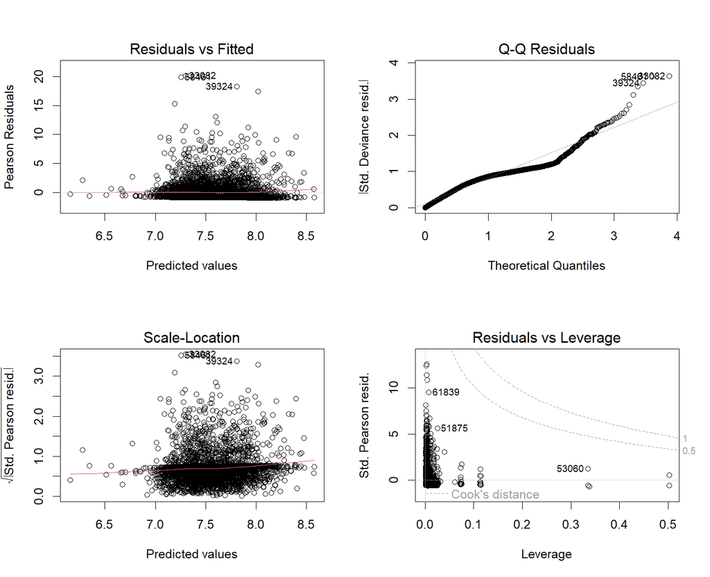

```r
par(mfrow = c(2, 2))
plot(model_gamma)   # residual vs fitted, Q-Q, scale-location, leverage
```

```r
par(mfrow = c(1, 1))
```

- **Residuals vs Fitted**: apakah ada pola sistematis (melengkung atau menyebar bentuk corong).
- **Q-Q**: residual deviance Gamma tidak harus persis mengikuti garis; ekor yang terlalu menyimpang menandakan klaim ekstrem yang tidak tertangkap model.
- **Scale-Location**: ragam relatif stabil bila garis kira-kira datar.
- **Leverage / Cook’s distance**: perhatikan observasi berpengaruh; klaim yang sangat besar bisa menarik koefisien. Pertimbangkan pengecekan dengan dan tanpa observasi tersebut.

## Prediksi biaya klaim

```r
klaim_baru <- data.frame(veh_value = 2, exposure = 0.5, veh_body = "SEDAN",
                         veh_age = 2, gender = "F", area = "F", agecat = 3)
predict(model_gamma, newdata = klaim_baru, type = "response")   # estimasi rata-rata biaya klaim (AUD)
```

```
#>        1
#> 2526.456
```

Secara matematis: η = β₀ + β₁x₁ + … + βₚxₚ, lalu E(Y | X) = e^η. Untuk Gamma dengan log link, `type = "response"` sudah mengembalikan nilai dalam **AUD**; `type = "link"` mengembalikan η pada skala log.

## Menggabungkan frekuensi dan severitas: premi murni

Dalam asuransi, **premi murni = frekuensi × severitas**. Model Poisson/NB memberi frekuensi, model Gamma memberi severitas.

```r
profil <- data.frame(veh_value = 2, exposure = 1, veh_body = "SEDAN",   # profil yang sama untuk kedua model
                     veh_age = 2, gender = "F", area = "C", agecat = 3)
frek <- predict(model_nb,    newdata = profil, type = "response")   # harapan klaim per tahun
sev  <- predict(model_gamma, newdata = profil, type = "response")   # harapan biaya per klaim (AUD)
c(frekuensi = frek, severitas = sev, premi_murni = frek * sev)
```

```
#>   frekuensi.1   severitas.1 premi_murni.1
#>     0.1700881  1294.0099729   220.0957490
```

Ini gambaran konsep. Dalam praktik, model Gamma sering dibobot dengan `weights = numclaims` dan diperlakukan sebagai **rata-rata biaya per klaim**, serta `exposure` tidak dijadikan predictor severitas. Versi di modul ini disederhanakan agar sejalan dengan latihan.

- Keluarkan `exposure` dari model Gamma. Apakah AIC berubah? Apakah masuk akal secara bisnis memasukkan `exposure` pada model severitas?
- Bandingkan koefisien Gamma dengan `lm(log(claimcst0) ~ ...)` pada data yang sama. Apa beda tafsir keduanya (rata-rata vs median/geometrik)?

# Part 6 · Ringkasan dan Alur Ujian

| Model | Response | Fungsi R | Link | Fokus pengecekan | Tafsir utama |
| --- | --- | --- | --- | --- | --- |
| Linear | Kontinu | `lm()` | Identity | linearitas, normalitas residual, homoskedastisitas, multikolinearitas (VIF) | β = perubahan rata-rata response |
| Logistik | 0/1 | `glm(family = binomial)` | Logit | separation, linearitas logit, kalibrasi, AUC | exp(β) = odds ratio |
| Poisson | Count | `glm(family = poisson)` + `offset(log(exposure))` | Log | equidispersion / overdispersion | exp(β) = pengali frekuensi |
| Negative Binomial | Count overdispersed | `MASS::glm.nb()` | Log | theta, AIC vs Poisson | exp(β) = pengali frekuensi |
| Gamma | Kontinu positif, miring | `glm(family = Gamma(link = "log"))` | Log | bentuk residual, outlier/influence | exp(β) = pengali rata-rata severitas |

## Workflow dari soal sampai interpretasi

1. **Identifikasi response**: kontinu biasa → Linear; 0/1 → Logistik; jumlah kejadian → Poisson/NB; biaya positif dan miring → Gamma.
2. **Tentukan kandidat predictor** dari konteks bisnis, tipe variabel, plot, dan korelasi.
3. **Pasang model awal**: `glm(response ~ x1 + x2 + x3, data = data, family = ...)`, lalu `summary()`.
4. **Tentukan variabel signifikan**: lihat p-value, dan untuk variabel kategorik gunakan `drop1()`. Jangan berhenti di p-value; cek AIC dan diagnostik.
5. **Tafsirkan koefisien**: Linear langsung β; Logistik/Poisson/Gamma lewat `exp(β)`. Sebutkan kategori pembanding dan syarat “predictor lain tetap”.
6. **Jika diminta prediksi**: `predict(model, newdata, type = "response")`; untuk model beroffset, sertakan `exposure` di `newdata`.

## Cheat sheet pertanyaan ujian

| Pertanyaan soal | Jawaban yang dicari |
| --- | --- |
| “Response 0/1?” | Logistik |
| “Jumlah klaim?” | Poisson → cek dispersion → NB jika overdispersed |
| “Biaya klaim > 0?” | Gamma + log link |
| “Koefisien Linear?” | Perubahan rata-rata response sebesar β |
| “Koefisien Logistik?” | Log-odds; ubah ke `exp(β)` = odds ratio |
| “Koefisien Poisson / NB?” | `exp(β)` = pengali frekuensi yang diharapkan |
| “Koefisien Gamma?” | `exp(β)` = pengali rata-rata severitas |
| “p-value < 0,05?” | Signifikan pada α = 5% |
| “Variabel kategorik banyak level?” | `drop1(model, test = "Chisq" / "F")` |
| “Poisson cocok?” | Cek count + indeks dispersi + dispersi Pearson |
| “Overdispersion?” | Negative Binomial (atau quasi-Poisson) |
| “Membandingkan model?” | `AIC()`; model bersarang: `anova(..., test = "Chisq")` |
| “Prediksi Logistik / Gamma?” | `type = "response"` → probabilitas / estimasi biaya |
| “Exposure?” | Model frekuensi: `offset(log(exposure))` |

**Pesan utama:**

- Urutan berpikir lebih penting daripada hafalan fungsi: **kenali response → pilih model → tentukan predictor → pasang → cek asumsi → cek signifikansi → tafsirkan → prediksi**.
- Tiga pasangan utama: **Logistik = 0/1 = odds/probabilitas**; **Poisson/NB = count = frekuensi/dispersi**; **Gamma = biaya positif miring = severitas**. Linear dipakai untuk memahami mekanisme regresi pada response kontinu biasa.
- Koefisien pada log link dan logit bersifat **perkalian** (lewat `exp(β)`), bukan penjumlahan.
- Signifikan secara statistik tidak sama dengan model yang baik. Pada data sebesar ini, periksa juga ukuran efek, kalibrasi, AUC, dan diagnostik.
- Model asuransi biasanya dibangun terpisah untuk **frekuensi** dan **severitas**, lalu digabung menjadi premi murni.

# Part 7 · Latihan Mandiri ala Ujian

Kerjakan memakai `dataCar` tanpa melihat bagian sebelumnya. Cocokkan pola kode Anda dengan **Contekan kode wajib**.

## Soal A · Logistik

1. Bentuk model `clm` dengan `veh_value`, `veh_age`, `gender`, `area`, dan `agecat`.
2. Tentukan variabel yang signifikan pada α = 5% (gunakan juga `drop1`).
3. Pilih satu variabel numerik dan tafsirkan koefisiennya.
4. Pilih satu variabel kategorik dan tafsirkan dibanding kategori pembanding.
5. Hitung odds ratio dengan `exp(β)` beserta selang kepercayaannya.
6. Prediksi probabilitas klaim untuk satu profil baru.

## Soal B · Poisson

1. Gunakan `numclaims` sebagai response; hitung rata-rata, ragam, dan indeks dispersi.
2. Tentukan apakah Poisson layak sebagai model awal.
3. Pasang Poisson dengan `offset(log(exposure))`.
4. Cek overdispersion dengan residual Pearson.
5. Jika overdispersion kuat, pasang Negative Binomial dan bandingkan AIC.
6. Tafsirkan satu koefisien numerik dan satu koefisien kategorik dengan `exp(β)`.

## Soal C · Gamma

1. Filter `claimcst0 > 0` dan buat histogram severitas.
2. Pasang Gamma dengan log link.
3. Identifikasi variabel signifikan dan hitung `exp(coef(model_gamma))`.
4. Tafsirkan satu koefisien numerik dan satu koefisien kategorik.
5. Prediksi biaya klaim untuk profil baru.
6. Periksa diagnostic plots.

## Soal D · Linear

1. Gunakan `veh_value` sebagai response dan pasang model penuh.
2. Tentukan kandidat model yang lebih sederhana dan bandingkan AIC.
3. Periksa residual vs fitted dan Q-Q plot; periksa multikolinearitas dengan `vif()`.
4. Tentukan koefisien yang signifikan dan tafsirkan minimal satu numerik dan satu kategorik.

# Part 8 · Contekan Kode Wajib

Semua kode berlabel **WAJIB** dirangkum di sini sebagai **pola** yang bisa dipakai ulang pada data lain. Hafalkan pola ini; kode diagnostik (PELENGKAP) cukup dilihat saat dibutuhkan.

```r
## 0. PERSIAPAN --------------------------------------------------------------
library(insuranceData); library(MASS); library(car)
data("dataCar", package = "insuranceData")
sapply(dataCar, class); colSums(is.na(dataCar))          # tipe variabel, data hilang
dataCar$veh_body <- relevel(dataCar$veh_body, ref = "SEDAN")   # atur kategori pembanding

## 1. LINEAR -------------------------------------------------------------------
m_lm <- lm(veh_value ~ veh_age + gender + area + agecat + exposure, data = dataCar)
summary(m_lm)                          # koefisien, p-value, R-squared
AIC(m_lm); drop1(m_lm, test = "F")     # bandingkan model; uji variabel kategorik utuh
vif(m_lm)                              # multikolinearitas
plot(m_lm)                             # diagnostik residual

## 2. LOGISTIK -----------------------------------------------------------------
m_lg <- glm(clm ~ veh_value + exposure + veh_age + gender + area + agecat,
            data = dataCar, family = binomial(link = "logit"))
summary(m_lg)
exp(cbind(OR = coef(m_lg), confint.default(m_lg)))            # odds ratio + selang 95%
drop1(m_lg, test = "Chisq")                                   # uji per variabel
predict(m_lg, newdata = polis_baru, type = "response")        # probabilitas klaim

## 3. POISSON / NEGATIVE BINOMIAL ---------------------------------------------
var(dataCar$numclaims) / mean(dataCar$numclaims)              # indeks dispersi
m_po <- glm(numclaims ~ veh_value + veh_age + gender + area + agecat + offset(log(exposure)),
            data = dataCar, family = poisson(link = "log"))
exp(coef(m_po))                                               # pengali frekuensi
sum(residuals(m_po, type = "pearson")^2) / df.residual(m_po)  # dispersi Pearson
m_nb <- glm.nb(numclaims ~ veh_value + veh_age + gender + area + agecat + offset(log(exposure)),
               data = dataCar)                                # jika overdispersion
AIC(m_po, m_nb)

## 4. GAMMA --------------------------------------------------------------------
data_gamma <- subset(dataCar, claimcst0 > 0)                  # hanya biaya positif
m_ga <- glm(claimcst0 ~ veh_value + exposure + veh_body + veh_age + gender + area + agecat,
            data = data_gamma, family = Gamma(link = "log"))
exp(coef(m_ga)); drop1(m_ga, test = "F")
predict(m_ga, newdata = klaim_baru, type = "response")        # estimasi biaya klaim (AUD)
```

**Pola yang selalu sama di setiap model:** (1) tentukan response dan family → (2) pilih predictor dan atur kategori pembanding → (3) `glm()` / `lm()` dan simpan ke objek → (4) `summary()` untuk koefisien dan p-value → (5) `exp(coef())` untuk tafsir perkalian, `drop1()` untuk variabel kategorik → (6) bandingkan model dengan `AIC()` → (7) cek diagnostik yang sesuai jenis model → (8) `predict(..., type = "response")` dengan `newdata` lengkap.

```
#> Dibuat dengan R version 4.6.1 (2026-06-24 ucrt)
```